# Credit Card Users Churn Prediction

##### Categorical variable Vs target Variable (Attrition_Flag)

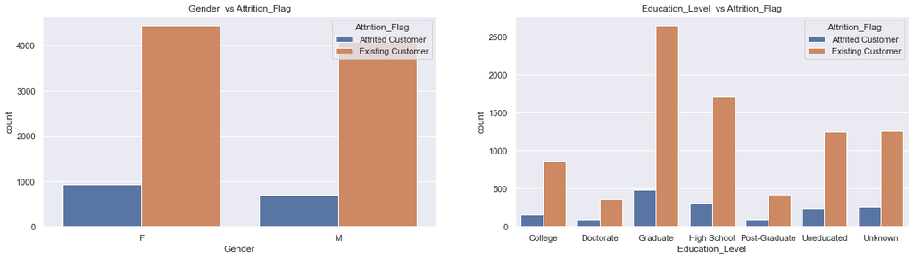

```python
fig, axes = plt.subplots(ncols=2,figsize=(20, 5))
sns.countplot(x='Gender',hue='Attrition_Flag',data=df,ax=axes[0]).set_title('Gender  vs Attrition_Flag')
sns.countplot(x='Education_Level',hue='Attrition_Flag',data=df,ax=axes[1]).set_title('Education_Level  vs Attrition_Flag')
```

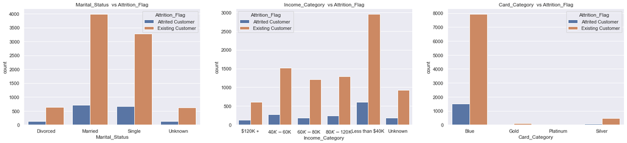

```python
fig, axes = plt.subplots(ncols=3,figsize=(25, 5))
sns.countplot(x='Marital_Status',hue='Attrition_Flag',data=df,ax=axes[0]).set_title('Marital_Status  vs Attrition_Flag')
sns.countplot(x='Income_Category',hue='Attrition_Flag',data=df,ax=axes[1]).set_title('Income_Category  vs Attrition_Flag')
sns.countplot(x='Card_Category',hue='Attrition_Flag',data=df,ax=axes[2]).set_title('Card_Category  vs Attrition_Flag')
```

**Observation**

- Graduate customers and uneducated customers has attrited more as compared to Doctrate or Post-Graduate
- Married and Single customers has attrited more as compared to Divorced or unknown
- Customers with income category Less than 40K and 40K-60K has attrited more as compared to other categories

##### Gender vs Credit_Limit

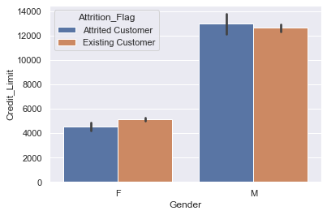

```python
sns.barplot(x='Gender', y='Credit_Limit',hue='Attrition_Flag',data=df)
```

##### Education_Level vs Credit_Limit

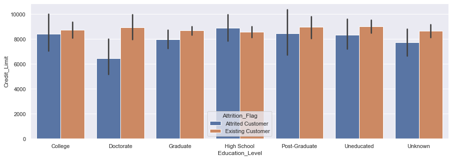

```python
plt.subplots(figsize=(15, 5))
sns.barplot(x='Education_Level', y='Credit_Limit',hue='Attrition_Flag',data=df)
```

##### Marital_Status vs Credit_Limit

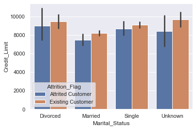

```python
sns.barplot(x='Marital_Status', y='Credit_Limit',hue='Attrition_Flag',data=df)
```

##### Card_Category vs Credit_Limit

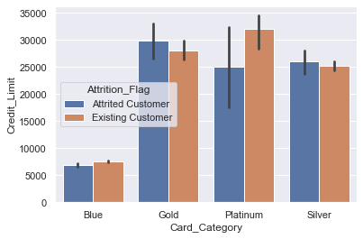

```python
sns.barplot(x='Card_Category', y='Credit_Limit',hue='Attrition_Flag',data=df)
```

##### Income_Category vs Credit_Limit

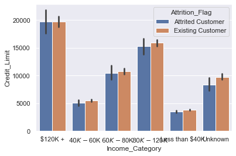

```python
sns.barplot(x='Income_Category', y='Credit_Limit',hue='Attrition_Flag',data=df)
```

**Observation**

- Income category, gender, martial status and card category is similar for both attrited and existing customer.
- 120K+ income category has the highest credit limit
- Platinum card has highest credit limit and customers with platinum card who attrited has lesser credit limit
- Female customers has lesser credit limit

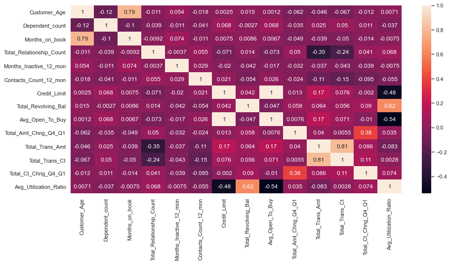

```python
plt.figure(figsize=(15, 7))
sns.heatmap(df.corr(), annot=True)
plt.show()
```

**Observation**

- Total_Trans_Amt and Total_Trans_Ct has high correlation (0.81)
- Months_on_book and Customer_Age has high correlation (0.79)
- Total_Revolving_Bal and Avg_Utilization_Ratio has high correlation (0.62)

### Replacing 'Unknow' with None for missing value treatment

```python
df = df.replace({'Unknown': None})
```

```python
df.isnull().sum().sort_values(ascending=False)
```

```
Education_Level             1519
Income_Category             1112
Marital_Status               749
Attrition_Flag                 0
Credit_Limit                   0
Total_Ct_Chng_Q4_Q1            0
Total_Trans_Ct                 0
Total_Trans_Amt                0
Total_Amt_Chng_Q4_Q1           0
Avg_Open_To_Buy                0
Total_Revolving_Bal            0
Months_Inactive_12_mon         0
Contacts_Count_12_mon          0
Customer_Age                   0
Total_Relationship_Count       0
Months_on_book                 0
Card_Category                  0
Dependent_count                0
Gender                         0
Avg_Utilization_Ratio          0
dtype: int64
```

### Replacing target categorical variable value to numeric value

```python
df['Attrition_Flag'] = df['Attrition_Flag'].replace({'Existing Customer': 0 ,'Attrited Customer':1})
```

### Split dataset into train, test and validation set

#### Separating target variable and other variables

```python
# Separating target variable and other variables
X = df.drop(columns="Attrition_Flag")
X = pd.get_dummies(X)
Y = df["Attrition_Flag"]
```

#### Split dataset into train, test and validation set

```python
# Splitting data into training, validation and test set:
# first we split data into 2 parts, say temporary and test

X_temp, X_test, y_temp, y_test = train_test_split(
    X, Y, test_size=0.2, random_state=1, stratify=Y
)

# then we split the temporary set into train and validation

X_train, X_val, y_train, y_val = train_test_split(
    X_temp, y_temp, test_size=0.25, random_state=1, stratify=y_temp
)
print(X_train.shape, X_val.shape, X_test.shape)
```

```
(6075, 34) (2026, 34) (2026, 34)
```

### Missing-Value Treatment

```python
imputer = KNNImputer(n_neighbors=10)
impute = imputer.fit(X_train)
X_train = impute.transform(X_train)
X_val = imputer.transform(X_val)
X_test = imputer.transform(X_test)
```

## Building the model

### Model can make wrong predictions as:

- Predicting a customer will churn but he does not
- Predicting a customer will not churn the services but he does

### Which case is more important?

- A loss of opportunity (ie. second case) - company failed to make a customer take the service due to wrong prediction which we want to minimize (loss of opportunity).

### How to reduce this loss i.e need to reduce False Negatives?

- recall should be maximized, the greater the recall lesser the chances of false negatives

### Model building

#### Let's start by building different models using KFold and cross_val_score and tune the best model using GridSearchCV and RandomizedSearchCV

Stratified K-Folds cross-validation provides dataset indices to split data into train/validation sets. Split dataset into k consecutive folds (without shuffling by default) keeping the distribution of both classes in each fold the same as the target variable. Each fold is then used once as validation while the k - 1 remaining folds form the training set.

#### Utility methods

```python
# defining a function to compute different metrics to check performance of a classification model built using sklearn
def model_performance_classification_sklearn(model, predictors, target):
    """
    Function to compute different metrics to check classification model performance

    model: classifier
    predictors: independent variables
    target: dependent variable
    """

    # predicting using the independent variables
    pred = model.predict(predictors)

    acc = accuracy_score(target, pred)  # to compute Accuracy
    recall = recall_score(target, pred)  # to compute Recall
    precision = precision_score(target, pred)  # to compute Precision
    f1 = f1_score(target, pred)  # to compute F1-score

    # creating a dataframe of metrics
    df_perf = pd.DataFrame(
        {
            "Accuracy": acc,
            "Recall": recall,
            "Precision": precision,
            "F1": f1,
        },
        index=[0],
    )

    return df_perf

def confusion_matrix_sklearn(model, predictors, target):
    """
    To plot the confusion_matrix with percentages

    model: classifier
    predictors: independent variables
    target: dependent variable
    """
    y_pred = model.predict(predictors)
    cm = confusion_matrix(target, y_pred)
    labels = np.asarray(
        [
            ["{0:0.0f}".format(item) + "\n{0:.2%}".format(item / cm.flatten().sum())]
            for item in cm.flatten()
        ]
    ).reshape(2, 2)

    plt.figure(figsize=(6, 4))
    sns.heatmap(cm, annot=labels, fmt="")
    plt.ylabel("True label")
    plt.xlabel("Predicted label")
    plt.show()


def StratifiedKFoldBasicModel(model,scoring,X_data,y_data):
    # Training the basic model with training set
    model.fit(X_data, y_data)
    kfold = StratifiedKFold(
        n_splits=5, shuffle=True, random_state=1
    )  # Setting number of splits equal to 5
    cv_result = cross_val_score(
        estimator=model, X=X_data, y=y_data, scoring=scoring, cv=kfold
    )
    return cv_result



def ModelValidationScore(models, names):
    # Plotting boxplots for CV scores of all models defined above
    fig = plt.figure(figsize=(10, 7))

    fig.suptitle("Algorithm Comparison")
    ax = fig.add_subplot(111)

    plt.boxplot(models)
    ax.set_xticklabels(names,rotation=90)

    plt.show()
```

```python
results = []  # Empty list to store all model's CV scores
names = []  # Empty list to store name of the models
```

#### BaggingClassifier

```python
bagging = BaggingClassifier(random_state=1)
bagging_cv_result=StratifiedKFoldBasicModel(bagging,"recall",X_train,y_train)
# Calculating different metrics on train set
bagging_model_train_perf = model_performance_classification_sklearn( bagging, X_train, y_train)
# Calculating different metrics on validation set
bagging_model_val_perf = model_performance_classification_sklearn(bagging, X_val, y_val)

results.append(bagging_cv_result)
names.append("BaggingClassifier")
```

#### RandomForestClassifier

```python
random = RandomForestClassifier(random_state=1)
random_cv_result=StratifiedKFoldBasicModel(random,"recall",X_train,y_train)
# Calculating different metrics on train set
random_model_train_perf = model_performance_classification_sklearn( random, X_train, y_train)
# Calculating different metrics on validation set
random_model_val_perf = model_performance_classification_sklearn(random, X_val, y_val)

results.append(random_cv_result)
names.append("RandomForestClassifier")
```

#### GradientBoostingClassifier

```python
gb = GradientBoostingClassifier(random_state=1)
gb_cv_result=StratifiedKFoldBasicModel(gb,"recall",X_train,y_train)
# Calculating different metrics on train set
gb_model_train_perf = model_performance_classification_sklearn( gb, X_train, y_train)
# Calculating different metrics on validation set
gb_model_val_perf = model_performance_classification_sklearn(gb, X_val, y_val)

results.append(gb_cv_result)
names.append("GradientBoostingClassifier")
```

#### AdaBoostClassifier

```python
ab = AdaBoostClassifier(random_state=1)
ab_cv_result=StratifiedKFoldBasicModel(ab,"recall",X_train,y_train)
# Calculating different metrics on train set
ab_model_train_perf = model_performance_classification_sklearn( ab, X_train, y_train)
# Calculating different metrics on validation set
ab_model_val_perf = model_performance_classification_sklearn(ab, X_val, y_val)

results.append(ab_cv_result)
names.append("AdaBoostClassifier")
```

#### XGBClassifier

```python
xgb = XGBClassifier(random_state=1,eval_metric="logloss")
xgb_cv_result=StratifiedKFoldBasicModel(xgb,"recall",X_train,y_train)
# Calculating different metrics on train set
xgb_model_train_perf = model_performance_classification_sklearn( xgb, X_train, y_train)
# Calculating different metrics on validation set
xgb_model_val_perf = model_performance_classification_sklearn(xgb, X_val, y_val)

results.append(xgb_cv_result)
names.append("XGBClassifier")
```

#### DecisionTreeClassifier

```python
dt = DecisionTreeClassifier(random_state=1)
dt_cv_result=StratifiedKFoldBasicModel(dt,"recall",X_train,y_train)
# Calculating different metrics on train set
dt_model_train_perf = model_performance_classification_sklearn( dt, X_train, y_train)
# Calculating different metrics on validation set
dt_model_val_perf = model_performance_classification_sklearn(dt, X_val, y_val)

results.append(dt_cv_result)
names.append("DecisionTreeClassifier")
```

#### Validation Score of different models

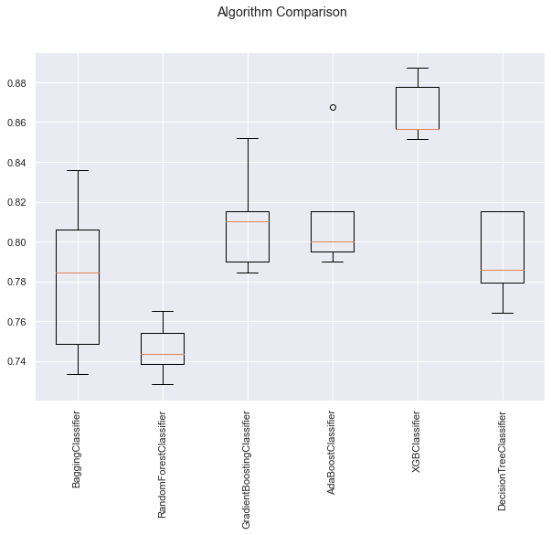

```python
ModelValidationScore(results,names)
```

**Observation**

- We can see thar Xgboost giving the highest cross-validated recall followed by Adaboost and GBM

### Model building - Oversampled data

#### Oversampling train data using SMOTE

```python
over_results = []  # Empty list to store all model's CV scores
over_names = []  # Empty list to store name of the models
```

```python
print("Before UpSampling, counts of label 'Existing Customer': {}".format(sum(y_train == 0)))
print("Before UpSampling, counts of label 'Attrited Customer': {} \n".format(sum(y_train == 1)))

sm = SMOTE(
    sampling_strategy=1, k_neighbors=5, random_state=1
)  # Synthetic Minority Over Sampling Technique
X_train_over, y_train_over = sm.fit_resample(X_train, y_train)


print("After UpSampling, counts of label 'Existing Customer: {}".format(sum(y_train_over == 0)))
print("After UpSampling, counts of label 'Attrited Customer': {} \n".format(sum(y_train_over == 1)))


print("After UpSampling, the shape of train_X: {}".format(X_train_over.shape))
print("After UpSampling, the shape of train_y: {} \n".format(y_train_over.shape))
```

```
Before UpSampling, counts of label 'Existing Customer': 5099
Before UpSampling, counts of label 'Attrited Customer': 976

After UpSampling, counts of label 'Existing Customer: 5099
After UpSampling, counts of label 'Attrited Customer': 5099

After UpSampling, the shape of train_X: (10198, 34)
After UpSampling, the shape of train_y: (10198,)
```

#### Bagging

```python
bagging_over = BaggingClassifier(random_state=1)
bagging_over_cv_result=StratifiedKFoldBasicModel(bagging_over,"recall",X_train_over,y_train_over)
# Calculating different metrics on train set
bagging_over_model_train_perf = model_performance_classification_sklearn( bagging_over, X_train_over, y_train_over)
# Calculating different metrics on validation set
bagging_over_model_val_perf = model_performance_classification_sklearn(bagging_over, X_val, y_val)

over_results.append(bagging_over_cv_result)
over_names.append("BaggingClassifier (Oversampled)")
```

#### RandomForestClassifier

```python
random_over = RandomForestClassifier(random_state=1)
random_over_cv_result=StratifiedKFoldBasicModel(random_over,"recall",X_train_over,y_train_over)
# Calculating different metrics on train set
random_over_model_train_perf = model_performance_classification_sklearn( random_over, X_train_over, y_train_over)
# Calculating different metrics on validation set
random_over_model_val_perf = model_performance_classification_sklearn(random_over, X_val, y_val)

over_results.append(random_over_cv_result)
over_names.append("RandomoverForestClassifier (Oversampled)")
```

#### GradientBoostingClassifier

```python
gb_over = GradientBoostingClassifier(random_state=1)
gb_over_cv_result=StratifiedKFoldBasicModel(gb_over,"recall",X_train_over,y_train_over)
# Calculating different metrics on train set
gb_over_model_train_perf = model_performance_classification_sklearn( gb_over, X_train_over, y_train_over)
# Calculating different metrics on validation set
gb_over_model_val_perf = model_performance_classification_sklearn(gb_over, X_val, y_val)

over_results.append(gb_over_cv_result)
over_names.append("GradientBoostingClassifier (Oversampled)")
```

#### AdaBoostClassifier

```python
ab_over = AdaBoostClassifier(random_state=1)
ab_over_cv_result=StratifiedKFoldBasicModel(ab_over,"recall",X_train_over,y_train_over)
# Calculating different metrics on train set
ab_over_model_train_perf = model_performance_classification_sklearn( ab_over, X_train_over, y_train_over)
# Calculating different metrics on validation set
ab_over_model_val_perf = model_performance_classification_sklearn(ab_over, X_val, y_val)

over_results.append(ab_over_cv_result)
over_names.append("AdaBoostClassifier (Oversampled)")
```

#### XGBClassifier

```python
xgb_over = XGBClassifier(random_state=1,eval_metric="logloss")
xgb_over_cv_result=StratifiedKFoldBasicModel(xgb_over,"recall",X_train_over,y_train_over)
# Calculating different metrics on train set
xgb_over_model_train_perf = model_performance_classification_sklearn( xgb_over, X_train_over, y_train_over)
# Calculating different metrics on validation set
xgb_over_model_val_perf = model_performance_classification_sklearn(xgb_over, X_val, y_val)

over_results.append(xgb_over_cv_result)
over_names.append("XGBClassifier (Oversampled)")
```

#### DecisionTreeClassifier

```python
dt_over = DecisionTreeClassifier(random_state=1)
dt_over_cv_result=StratifiedKFoldBasicModel(dt_over,"recall",X_train_over,y_train_over)
# Calculating different metrics on train set
dt_over_model_train_perf = model_performance_classification_sklearn( dt_over, X_train_over, y_train_over)
# Calculating different metrics on validation set
dt_over_model_val_perf = model_performance_classification_sklearn(dt_over, X_val, y_val)

over_results.append(dt_over_cv_result)
over_names.append("DecisionTreeClassifier (Oversampled)")
```

#### Validation Score of different models with Oversample data

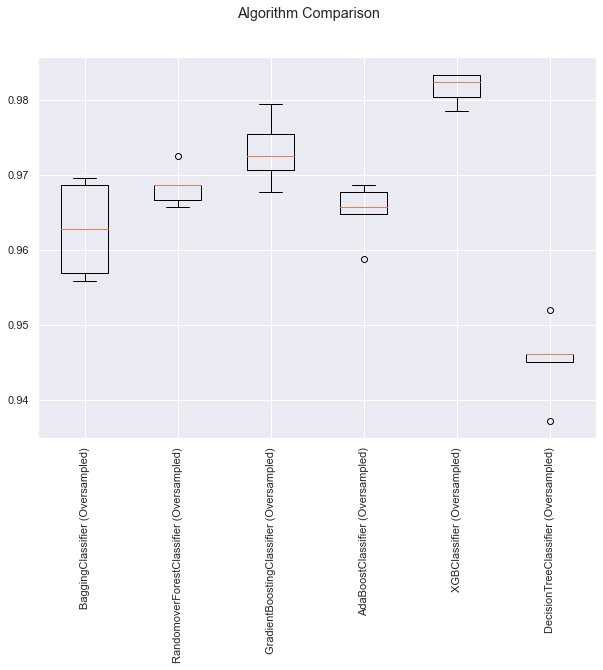

```python
ModelValidationScore(over_results,over_names)
```

**Observation**

- We can see thar Xgboost giving the highest cross-validated recall followed by GradientBoosting

### Undersampling train data using Random Under Sampler

```python
un_results = []  # Empty list to store all model's CV scores
un_names = []  # Empty list to store name of the models
```

```python
rus = RandomUnderSampler(random_state=1)
X_train_un, y_train_un = rus.fit_resample(X_train, y_train)
```

```python
print("Before Under Sampling, counts of label 'Existing Customer': {}".format(sum(y_train == 0)))
print("Before Under Sampling, counts of label 'Attrited Customer': {} \n".format(sum(y_train == 1)))

print("After Under Sampling, counts of label 'Existing Customer': {}".format(sum(y_train_un == 0)))
print("After Under Sampling, counts of label 'Attrited Customer': {} \n".format(sum(y_train_un == 1)))

print("After Under Sampling, the shape of train_X: {}".format(X_train_un.shape))
print("After Under Sampling, the shape of train_y: {} \n".format(y_train_un.shape))
```

```
Before Under Sampling, counts of label 'Existing Customer': 5099
Before Under Sampling, counts of label 'Attrited Customer': 976

After Under Sampling, counts of label 'Existing Customer': 976
After Under Sampling, counts of label 'Attrited Customer': 976

After Under Sampling, the shape of train_X: (1952, 34)
After Under Sampling, the shape of train_y: (1952,)
```

#### Bagging

```python
bagging_un = BaggingClassifier(random_state=1)
bagging_un_cv_result=StratifiedKFoldBasicModel(bagging_un,"recall",X_train_un,y_train_un)
# Calculating different metrics on train set
bagging_un_model_train_perf = model_performance_classification_sklearn( bagging_un, X_train_un, y_train_un)
# Calculating different metrics on validation set
bagging_un_model_val_perf = model_performance_classification_sklearn(bagging_un, X_val, y_val)

un_results.append(bagging_un_cv_result)
un_names.append("BaggingClassifier (Undersampled)")
```

#### RandomForestClassifier

```python
random_un = RandomForestClassifier(random_state=1)
random_un_cv_result=StratifiedKFoldBasicModel(random_un,"recall",X_train_un,y_train_un)
# Calculating different metrics on train set
random_un_model_train_perf = model_performance_classification_sklearn( random_un, X_train_un, y_train_un)
# Calculating different metrics on validation set
random_un_model_val_perf = model_performance_classification_sklearn(random_un, X_val, y_val)

un_results.append(random_un_cv_result)
un_names.append("RandomunForestClassifier (Undersampled)")
```

#### GradientBoostingClassifier

```python
gb_un = GradientBoostingClassifier(random_state=1)
gb_un_cv_result=StratifiedKFoldBasicModel(gb_un,"recall",X_train_un,y_train_un)
# Calculating different metrics on train set
gb_un_model_train_perf = model_performance_classification_sklearn( gb_un, X_train_un, y_train_un)
# Calculating different metrics on validation set
gb_un_model_val_perf = model_performance_classification_sklearn(gb_un, X_val, y_val)

un_results.append(gb_un_cv_result)
un_names.append("GradientBoostingClassifier (Undersampled)")
```

#### AdaBoostClassifier

```python
ab_un = AdaBoostClassifier(random_state=1)
ab_un_cv_result=StratifiedKFoldBasicModel(ab_un,"recall",X_train_un,y_train_un)
# Calculating different metrics on train set
ab_un_model_train_perf = model_performance_classification_sklearn( ab_un, X_train_un, y_train_un)
# Calculating different metrics on validation set
ab_un_model_val_perf = model_performance_classification_sklearn(ab_un, X_val, y_val)

un_results.append(ab_un_cv_result)
un_names.append("AdaBoostClassifier (Undersampled)")
```

#### XGBClassifier

```python
xgb_un = XGBClassifier(random_state=1,eval_metric="logloss")
xgb_un_cv_result=StratifiedKFoldBasicModel(xgb_un,"recall",X_train_un,y_train_un)
# Calculating different metrics on train set
xgb_un_model_train_perf = model_performance_classification_sklearn( xgb_un, X_train_un, y_train_un)
# Calculating different metrics on validation set
xgb_un_model_val_perf = model_performance_classification_sklearn(xgb_un, X_val, y_val)

un_results.append(xgb_un_cv_result)
un_names.append("XGBClassifier (Undersampled)")
```

#### DecisionTreeClassifier

```python
dt_un = DecisionTreeClassifier(random_state=1)
dt_un_cv_result=StratifiedKFoldBasicModel(dt_un,"recall",X_train_un,y_train_un)
# Calculating different metrics on train set
dt_un_model_train_perf = model_performance_classification_sklearn( dt_un, X_train_un, y_train_un)
# Calculating different metrics on validation set
dt_un_model_val_perf = model_performance_classification_sklearn(dt_un, X_val, y_val)

un_results.append(dt_un_cv_result)
un_names.append("DecisionTreeClassifier (Undersampled)")
```

#### Validation Score of different models with Undersample data

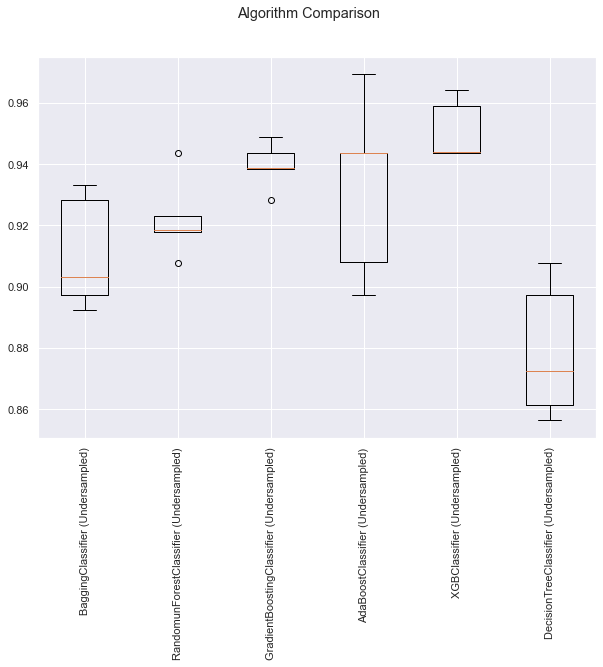

```python
ModelValidationScore(un_results,un_names)
```

**Observation**

- We can see thar Xgboost giving the highest cross-validated recall followed by Adaboost

### Model Comparison

```python
models_train_comp_df = pd.concat([bagging_model_train_perf.T,random_model_train_perf.T,gb_model_train_perf.T,ab_model_train_perf.T,xgb_model_train_perf.T,dt_model_train_perf.T,
bagging_over_model_train_perf.T,random_over_model_train_perf.T,gb_over_model_train_perf.T,ab_over_model_train_perf.T,xgb_over_model_train_perf.T,dt_over_model_train_perf.T,
bagging_un_model_train_perf.T,random_un_model_train_perf.T,gb_un_model_train_perf.T,ab_un_model_train_perf.T,xgb_un_model_train_perf.T,dt_un_model_train_perf.T
],axis=1)

models_train_comp_df.columns = [
    "Bagging","RandomunFores", "GradientBoosting","AdaBoost","XGB","DecisionTree",
    "Bagging (Oversampled)","RandomunFores (Oversampled)", "GradientBoosting (Oversampled)","AdaBoost (Oversampled)","XGB (Oversampled)","DecisionTree (Oversampled)",
    "Bagging (Undersampled)","RandomunFores (Undersampled)", "GradientBoosting (Undersampled)","AdaBoost (Undersampled)","XGB (Undersampled)","DecisionTree (Undersampled)"]


print("Training performance comparison:")
models_train_comp_df.T.sort_values(by='Recall',ascending=False)
```

```
Training performance comparison:
```

|  | Accuracy | Recall | Precision | F1 |
| --- | --- | --- | --- | --- |
| DecisionTree (Undersampled) | 1.00 | 1.00 | 1.00 | 1.00 |
| DecisionTree (Oversampled) | 1.00 | 1.00 | 1.00 | 1.00 |
| XGB (Undersampled) | 1.00 | 1.00 | 1.00 | 1.00 |
| RandomunFores (Undersampled) | 1.00 | 1.00 | 1.00 | 1.00 |
| XGB | 1.00 | 1.00 | 1.00 | 1.00 |
| DecisionTree | 1.00 | 1.00 | 1.00 | 1.00 |
| RandomunFores (Oversampled) | 1.00 | 1.00 | 1.00 | 1.00 |
| RandomunFores | 1.00 | 1.00 | 1.00 | 1.00 |
| XGB (Oversampled) | 1.00 | 1.00 | 1.00 | 1.00 |
| Bagging (Oversampled) | 1.00 | 1.00 | 1.00 | 1.00 |
| Bagging (Undersampled) | 1.00 | 0.99 | 1.00 | 1.00 |
| Bagging | 1.00 | 0.99 | 1.00 | 0.99 |
| GradientBoosting (Undersampled) | 0.98 | 0.98 | 0.97 | 0.98 |
| GradientBoosting (Oversampled) | 0.98 | 0.98 | 0.98 | 0.98 |
| AdaBoost (Oversampled) | 0.97 | 0.97 | 0.97 | 0.97 |
| AdaBoost (Undersampled) | 0.95 | 0.95 | 0.95 | 0.95 |
| GradientBoosting | 0.97 | 0.88 | 0.95 | 0.91 |
| AdaBoost | 0.96 | 0.84 | 0.90 | 0.87 |

```python
models_val_comp_df = pd.concat([bagging_model_val_perf.T,random_model_val_perf.T,gb_model_val_perf.T,ab_model_val_perf.T,xgb_model_val_perf.T,dt_model_val_perf.T,
bagging_over_model_val_perf.T,random_over_model_val_perf.T,gb_over_model_val_perf.T,ab_over_model_val_perf.T,xgb_over_model_val_perf.T,dt_over_model_val_perf.T,
bagging_un_model_val_perf.T,random_un_model_val_perf.T,gb_un_model_val_perf.T,ab_un_model_val_perf.T,xgb_un_model_val_perf.T,dt_un_model_val_perf.T
],axis=1)

models_val_comp_df.columns = [
    "Bagging","RandomunFores", "GradientBoosting","AdaBoost","XGB","DecisionTree",
    "Bagging (Oversampled)","RandomunFores (Oversampled)", "GradientBoosting (Oversampled)","AdaBoost (Oversampled)","XGB (Oversampled)","DecisionTree (Oversampled)",
    "Bagging (Undersampled)","RandomunFores (Undersampled)", "GradientBoosting (Undersampled)","AdaBoost (Undersampled)","XGB (Undersampled)","DecisionTree (Undersampled)"]


print("Validation performance comparison:")
models_val_comp_df.T.sort_values(by='Recall',ascending=False)
```

```
Validation performance comparison:
```

|  | Accuracy | Recall | Precision | F1 |
| --- | --- | --- | --- | --- |
| XGB (Undersampled) | 0.94 | 0.97 | 0.74 | 0.84 |
| AdaBoost (Undersampled) | 0.93 | 0.96 | 0.70 | 0.81 |
| GradientBoosting (Undersampled) | 0.93 | 0.95 | 0.72 | 0.82 |
| RandomunFores (Undersampled) | 0.93 | 0.94 | 0.71 | 0.81 |
| Bagging (Undersampled) | 0.92 | 0.92 | 0.70 | 0.79 |
| DecisionTree (Undersampled) | 0.89 | 0.90 | 0.61 | 0.73 |
| XGB (Oversampled) | 0.97 | 0.90 | 0.91 | 0.91 |
| XGB | 0.97 | 0.89 | 0.93 | 0.91 |
| GradientBoosting (Oversampled) | 0.96 | 0.89 | 0.88 | 0.88 |
| AdaBoost (Oversampled) | 0.95 | 0.88 | 0.81 | 0.85 |
| AdaBoost | 0.96 | 0.86 | 0.89 | 0.87 |
| Bagging (Oversampled) | 0.95 | 0.86 | 0.82 | 0.84 |
| GradientBoosting | 0.97 | 0.86 | 0.94 | 0.90 |
| DecisionTree (Oversampled) | 0.93 | 0.83 | 0.75 | 0.79 |
| DecisionTree | 0.94 | 0.82 | 0.82 | 0.82 |
| Bagging | 0.95 | 0.80 | 0.90 | 0.85 |
| RandomunFores (Oversampled) | 0.95 | 0.80 | 0.87 | 0.83 |
| RandomunFores | 0.95 | 0.79 | 0.91 | 0.85 |

**Observation**

- XGB, AdaBoost and GradientBoost with undersampled data provided better result for recall.
- These 3 models is provided better score on validation data, we will further tune these three models